# Analysis of the trend of Michigan Consumer Sentiment Index in the past and prediction in the future

3/1/2020

## 1.Introduction

Many people have heard about the concept of GDP(gross domestic product), which is a measurement of a country’s productivity level. Also, there are many other indices which could represent the price level of a country, consumers’ standard of living, etc. From these indices, Economists and Econometricians are able to analyze the trend of a country’s Economy and Effectivity in the long run and do the do the prediction. Here, we are introducing a new index: The Michigan Consumer Sentiment Index (MCSI). It is a monthly survey of the U.S. consumer confidence levels conducted by the University of Michigan. It is based on telephone surveys that gather information on consumer expectations regarding the overall economy. The base index is 100 and based on Year 1966. The index, introduced in 1946 by George Katona at the university, is designed to capture the mood of American consumers with regard to their economic well-being and outlook. Whether the sentiment is optimistic, pessimistic or neutral, it signals general information about near-term consumer spending plans (Kenton, 2019).Each month a minimum of 500 phone interviews are conducted across the continental U.S. There are around 50 core questions that cover three broad areas of consumer sentiment: personal finances, business condition, and buying conditions (Kenton, 2019). Therefore, as a leading index, we can investigate the impact of the demand of market on the trend of Economic business cycle.

## 2.Objectives

The goal of this study is to perform a time-series analysis of the Michigan Consumer Sentiment Index (MCSI). To explore more information on how consumer sentiment changing over time, we will apply basic time-series models(such as basic ARMA model) and techniques(such as detrend) to the data. Then, we will check stationarity of monthly sentiment series by either root test or Dickey-Fuller test even we haven’t covered yet. If our data indicates some trend effects, we should do ARIMA model to deal with the non-stationarity problem, at least we can try to solve it. Now, we could do model-selecting by AIC table and model-checking plots to assess different fitted models of the differenced series. Finally,we will further assess whether monthly consumer sentiment exhibits certain cyclical or periodic behavior so that we could add SARIMA model to adjust our seasonality change. The average length of the stochastic cycles will be obtained and hence, we could validate the model by comparing the predicted values to the actuals.

## 3.Data Analysis

### 3.1 Descriptive Statistics

```r
#Detrend series
chg<-diff(csent)
schg<-diff(chg, 4)
summary(csent)
```

```
##    Min. 1st Qu.  Median    Mean 3rd Qu.    Max.
##   61.20   76.40   93.00   88.38   97.15  112.00
```

```r
summary(schg)
```

```
##    Min. 1st Qu.  Median    Mean 3rd Qu.    Max.
## -39.900  -8.975  -3.550  -1.919  10.875  29.500
```

Then we look at the histogram as well as the ts plots.

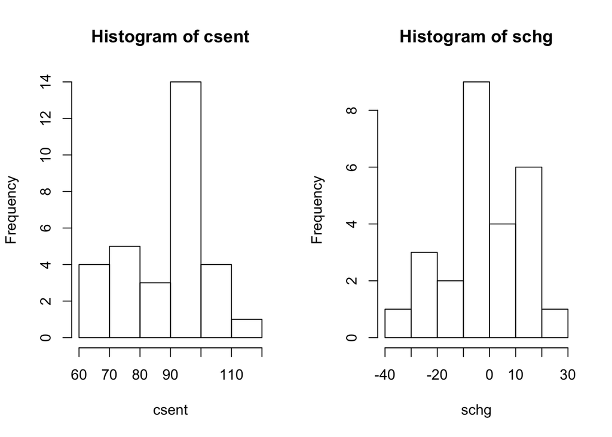

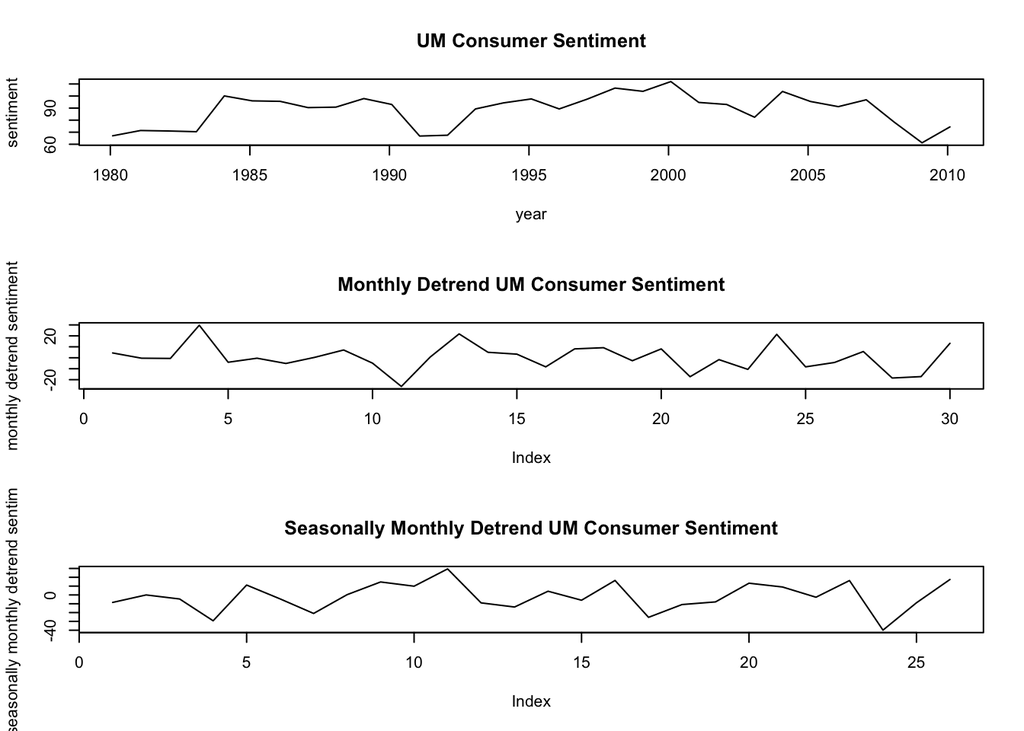

Both histograms illustrate bell shapes, which is an indication of the normality assumption. To explore more information on how MCSI changing over time, we check the time series plot for MCSI. It is obvious that the unbounded time series plot exhibits some trend effects. After we apply the difference by $1^{st}$ order to our data, it looks that the trend effect goes away; The Seasonality monthly data(difference by $4^{th}$ order), shows that the weekly detrend data has the same pattern as monthly detrend data.

### 3.2 Check Stationarity

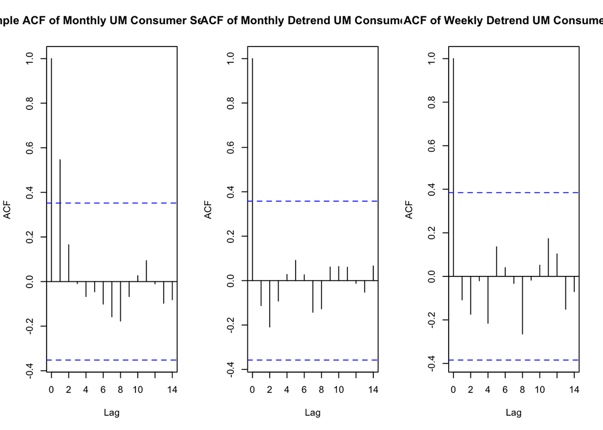

### 3.3 Augumented Dickey Fuller test

```r
adfTest(csent,type="nc")
```

```
##
## Title:
##  Augmented Dickey-Fuller Test
##
## Test Results:
##   PARAMETER:
##     Lag Order: 1
##   STATISTIC:
##     Dickey-Fuller: -0.284
##   P VALUE:
##     0.5184
##
## Description:
##  Wed Mar 18 20:15:09 2020 by user:
```

```r
adfTest(chg,type="nc")
```

```
##
## Title:
##  Augmented Dickey-Fuller Test
##
## Test Results:
##   PARAMETER:
##     Lag Order: 1
##   STATISTIC:
##     Dickey-Fuller: -4.7765
##   P VALUE:
##     0.01
##
## Description:
##  Wed Mar 18 20:15:09 2020 by user:
```

In Econometrics, we usually use Augumented Dickey Fuller to test if we could reject the null hypothesis that a unit root is present in an autoregressive model, indicates a non-stationarity. From the result on testing the original data $\textit{csent}$, the p-value is very high and we fail to reject the NH and conclude that there is a unit root in the monthly sentiment series, implies the model in this data is not stationary. However, the result on the transformed data $\textit{chg}$ gives us enough evidence to reject the NH and it suggests us differenced data is more suitable in our model. The result confirms the Sample ACF plots in 3.2.

### 3.4 Select the ARIMA model.

ARIMA(p,1,q) Model: $\phi(B)((1-B)Y_{n}-\mu)=\psi(B)\epsilon_{n}$, where $\epsilon_{n}$ follows a Guassian distribution with i.i.d variance (0, $\sigma^2$); $\phi(x)$and$\psi(x)$ are ARMA polynomials. Another Concept: Transformation to stationarity: $z_{n}=y_{n}-y_{n-1}$, where is the difference by $1^{st}$ order.

Noted that ARIMA(p,1,q) Model is almost like a special ARMA(p+1,q) Model with a unit root, due to the strong serial dependence identified from the sample ACFs, we consider the differenced data $\textit{chg}$: monthly MCSI after detrend instead of original data $\textit{csent}$.

$\textbf{Since we are using differenced data, there is no need to build ARIMA model and we could use ARMA model direclty to represent ARIMA model}$

Thus, we would say ARMA model in convenience but actually it is an ARIMA model based on not transformed data.

Check AIC table for different ARMA model based on $\textit{chg}$.

```r
kable(midchgtable,digits=3)
```

|  | MA0 | MA1 | MA2 | MA3 | MA4 | MA5 |
| --- | --- | --- | --- | --- | --- | --- |
| AR0 | 238.186 | 239.464 | 239.517 | 240.394 | 242.141 | 244.140 |
| AR1 | 239.799 | 238.592 | 240.122 | 242.114 | 244.143 | 246.141 |
| AR2 | 240.261 | 240.131 | 242.117 | 244.112 | 246.114 | 248.076 |
| AR3 | 241.458 | 242.111 | 243.919 | 246.111 | 246.864 | 248.223 |
| AR4 | 243.329 | 245.319 | 246.108 | 247.835 | 249.028 | 250.925 |
| AR5 | 245.313 | 247.313 | 248.066 | 248.937 | 249.793 | 252.444 |

```r
chgmod<-arima(chg,order=c(3,0,3),include.mean=F)
chgmod
```

```
##
## Call:
## arima(x = chg, order = c(3, 0, 3), include.mean = F)
##
## Coefficients:
##          ar1      ar2     ar3      ma1     ma2      ma3
##       0.9070  -1.1337  0.6244  -1.1863  1.1863  -1.0000
## s.e.  0.2988   0.2265  0.2260   0.2829  0.2820   0.2369
##
## sigma^2 estimated as 107.8:  log likelihood = -114.73,  aic = 243.46
```

```r
chgmod2<-arima(chg,order=c(5,0,0),include.mean=F)
chgmod2
```

```
##
## Call:
## arima(x = chg, order = c(5, 0, 0), include.mean = F)
##
## Coefficients:
##           ar1      ar2      ar3      ar4     ar5
##       -0.1751  -0.2633  -0.1749  -0.0716  0.0279
## s.e.   0.1846   0.1944   0.2008   0.2207  0.2158
##
## sigma^2 estimated as 129.8:  log likelihood = -115.67,  aic = 243.35
```

### 3.5 Check the significance of model.

```r
AR_roots<-polyroot(c(1,-coef(chgmod)[c("ar1","ar2","ar3")]))
abs(AR_roots)
```

```
## [1] 1.017770 1.017770 1.546075
```

```r
MA_roots<-polyroot(c(1,-coef(chgmod)[c("ma1","ma2","ma3")]))
abs(MA_roots)
```

```
## [1] 0.4952569 1.4209864 1.4209864
```

```r
AR_roots2<-polyroot(c(1,-coef(chgmod2)[c("ar1","ar2","ar3","ar4","ar5")]))
abs(AR_roots2)
```

```
## [1] 1.492979 1.879751 1.492979 1.879751 4.549751
```

Construct a 95% Confidence Interval and see if the ar roots from AMRA(5,0) is significant.

```r
confint(chgmod2)
```

```
##          2.5 %    97.5 %
## ar1 -0.5369749 0.1867739
## ar2 -0.6443533 0.1177931
## ar3 -0.5685097 0.2186592
## ar4 -0.5042591 0.3610422
## ar5 -0.3950846 0.4508974
```

### 3.6 Residual Analysis.

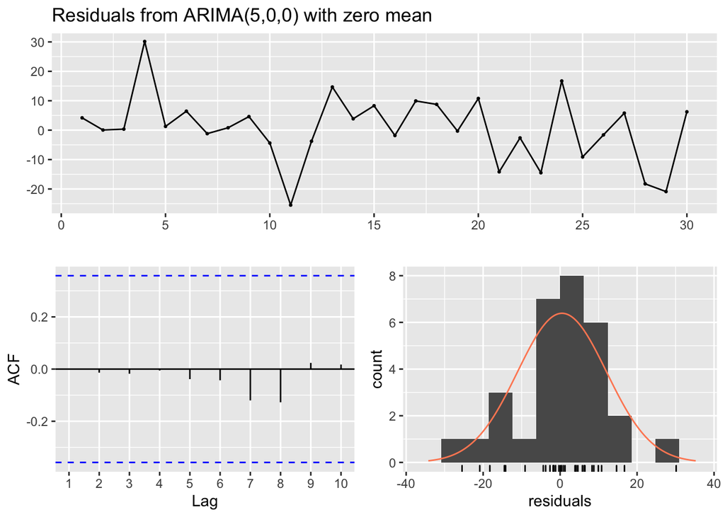

```
##
##  Ljung-Box test
##
## data:  Residuals from ARIMA(5,0,0) with zero mean
## Q* = 1.4582, df = 3, p-value = 0.692
##
## Model df: 5.   Total lags used: 8
```

```r
#We use the R package(forecast)
checkresiduals(chgmod2)
```

The first graph(Residual plot) shows that residuals oscillate over time, it can be observed that residuals deviated from zero, which is consistent with the pattern of gaussian white noise. Then, looking at the second graph (ACF of the residuals), additional serial correlations are not shown since no lag shows suspicious correlations between lags. From the third plot, the histogram of residuals are in a good shape of normal distribution(mean=0), so that we have evidence to say our white noise {$\epsilon_{n}$} meets the Normality assumption with zero mean and constant variance (0, $\sigma^2$).

Box-Ljung test is not required in the class, but it is an alternative method to verify if the residuals are white noise, which does not contain serial dependence.

```r
#using the Box-Ljung test
Box.test(chgmod2$residuals,lag=12,type='Ljung')
```

```
##
##  Box-Ljung test
##
## data:  chgmod2$residuals
## X-squared = 1.8765, df = 12, p-value = 0.9996
```

We set the lag=12 because we want to check if we could reject the null hypothesis that residuals have no auto correlation in the first 12 months. The very large p-value tells us that we can not reject the NH so that ARMA(5,0) model doesn’t violate the residual assumptions.

## 4.Spectrum Analysis and Periodic Interpretation

```r
#First, do the unsmoothed periodogram
Spec0<-spectrum(chg, main = "Unsmoothed periodogram in pgram estimation")
```

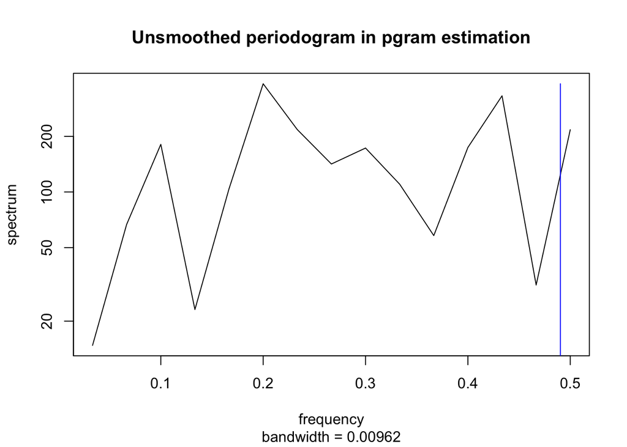

```r
#Next, do the smoothed periodogram with span(3,6,3)
Spec1<-spectrum(chg, spans=c(3,6,3), main = "Smoothed periodogram")
```

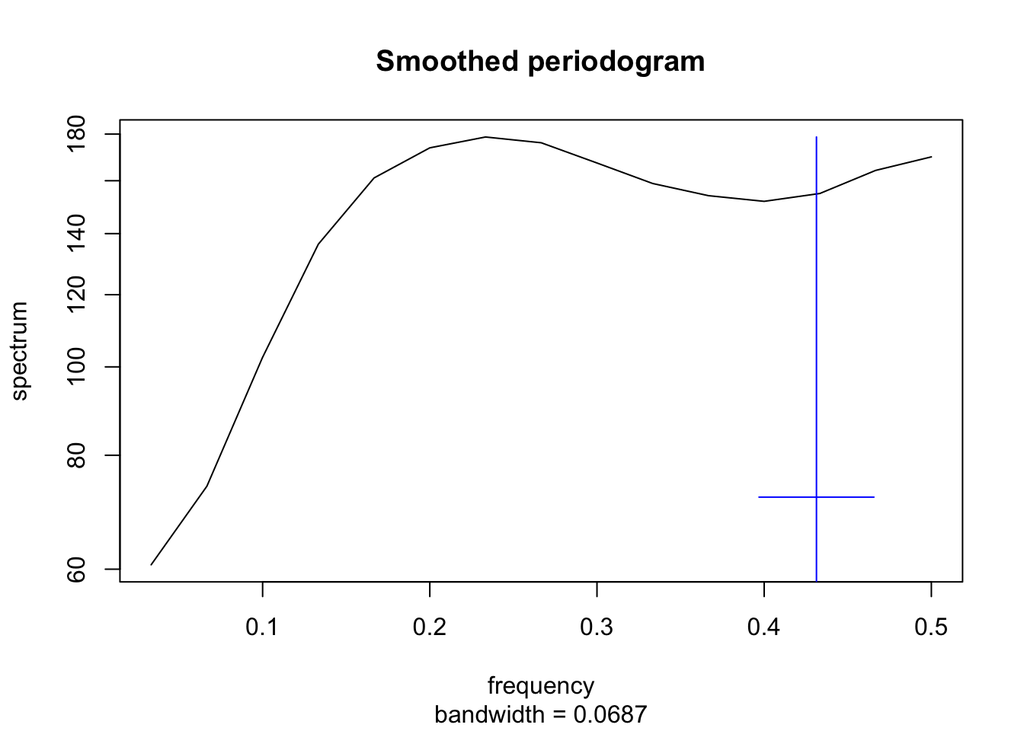

```r
a<-Spec1$freq[which.max(Spec1$spec)]
1/a
```

```
## [1] 4.285714
```